# Lab 4 team file

Jacob Shoemaker; jshoemaker2249, Qinwen Yang; AngelQinwen

3/27/2019

# Part one: Cleaning Data

1.Load data and rename columns

```r
library(readxl)
library(dplyr)
```

```r
library(tidyr)
library(ggplot2)
defense <- read_excel('cyclonesFootball2018.xlsx', sheet='Defensive')
offense <- read_excel('cyclonesFootball2018.xlsx', sheet='Offensive')
biography <- read_excel('cyclonesFootball2018.xlsx', sheet='Biography')
str(defense)
```

```
## Classes 'tbl_df', 'tbl' and 'data.frame':    446 obs. of  11 variables:
##  $ Name             : chr  "Eisworth, Greg" "Eisworth, Greg" "Eisworth, Greg" "Eisworth, Greg" ...
##  $ Opponent_Opponent: chr  "Iowa" "Oklahoma" "Akron" "TCU" ...
##  $ Tackles_Solo     : chr  "3" "6" "7" "6" ...
##  $ Tackles_ASST     : chr  "3" "8" "2" "3" ...
##  $ Tackles_TFL      : chr  "0" "1.0" "1.0" "0" ...
##  $ Tackles_Sack     : chr  "0" "0" "0" "0" ...
##  $ Turnover_FF      : chr  "0" "1" "0" "0" ...
##  $ Turnover_FR      : chr  "0" "0" "0" "0" ...
##  $ Turnover_INT     : chr  "0" "0" "0" "0" ...
##  $ Pass_QBH         : chr  "0" "0" "0" "0" ...
##  $ Pass_PB          : chr  "0" "0" "3" "0" ...
```

```r
str(offense)
```

```
## Classes 'tbl_df', 'tbl' and 'data.frame':    168 obs. of  12 variables:
##  $ Name             : chr  "Jones, Deshaunte" "Jones, Deshaunte" "Jones, Deshaunte" "Jones, Deshaunte" ...
##  $ Opponent_Opponent: chr  "Iowa" "Oklahoma" "Akron" "TCU" ...
##  $ Receiving_REC    : chr  "1" "9" "6" "3" ...
##  $ Receiving_YDS    : chr  "31" "66" "39" "23" ...
##  $ Receiving_TD     : chr  "0" "0" "0" "0" ...
##  $ Rushing_ATT      : chr  NA NA NA NA ...
##  $ Rushing_YDS      : chr  NA NA NA NA ...
##  $ Rushing_TD       : chr  NA NA NA NA ...
##  $ Passing_CMP-ATT  : chr  NA NA NA NA ...
##  $ Passing_YDS      : chr  NA NA NA NA ...
##  $ Passing_TD       : chr  NA NA NA NA ...
##  $ Passing_INT      : chr  NA NA NA NA ...
```

```r
str(biography)
```

```
## Classes 'tbl_df', 'tbl' and 'data.frame':    123 obs. of  7 variables:
##  $ Name      : chr  "Akers, Landen" "Allen, Chase" "Alt, Gerry" "Anderson, Cole" ...
##  $ Position  : chr  "Wide Receiver" "Tight End" "Offensive Line" "Tight End" ...
##  $ Height    : chr  "6-0" "6-7" "6-2" "6-4" ...
##  $ Weight    : chr  "192" "240" "290" "250" ...
##  $ Class     : chr  "Redshirt Sophomore" "Redshirt Sophomore" "Redshirt Freshman" "Redshirt Senior" ...
##  $ Hometown  : chr  "Cedar Rapids, Iowa" "Nixa, Mo." "Cedar Rapids, Iowa" "League City, Texas" ...
##  $ Highschool: chr  "Washington" "Nixa" "Washington" "Clear Falls" ...
```

```r
#Rename the Opponent_Opponent to Opponent in offense and defense.
defense <- defense %>% rename(Opponent = Opponent_Opponent)
offense <- offense %>% rename(Opponent = Opponent_Opponent)
```

2. The player names and opponent names are factors.

```r
offense <- offense %>%
  mutate(Opponent = factor(Opponent),
         Name = factor(Name))

defense <- defense %>%
  mutate(Opponent = factor(Opponent),
         Name = factor(Name))

biography <- biography %>%
  mutate(Name = factor(Name))
```

3. All offensive and defensive statistics are numerical. The Weight column in biography is also numeric.

```r
#?mutate_at
defense <- defense %>% mutate_at(vars(Tackles_Solo : Pass_PB), funs(as.numeric))
offense <- offense %>% mutate_at(vars(Receiving_REC : Passing_INT), funs(as.numeric))
```

```r
biography <- biography %>% mutate(Weight = as.numeric(Weight))
```

4. Bonus: Change the Height column in biography into numeric.

```r
SepHeight <- biography %>% separate(Height, into=c('feet', 'inches'), sep = "-")
SepHeight
```

```
## # A tibble: 123 x 8
##    Name      Position   feet  inches Weight Class    Hometown    Highschool
##    <fct>     <chr>      <chr> <chr>   <dbl> <chr>    <chr>       <chr>
##  1 Akers, L… Wide Rece… 6     0         192 Redshir… Cedar Rapi… Washington
##  2 Allen, C… Tight End  6     7         240 Redshir… Nixa, Mo.   Nixa
##  3 Alt, Ger… Offensive… 6     2         290 Redshir… Cedar Rapi… Washington
##  4 Anderson… Tight End  6     4         250 Redshir… League Cit… Clear Fal…
##  5 Assalley… Placekick… 6     0         191 Redshir… Naperville… Central
##  6 Austin, … Linebacker 5     11        205 Redshir… Walnut, Ca… Bishop Am…
##  7 Azunna, … Defensive… 6     0         192 Redshir… Grand Prai… Lake Ridge
##  8 Bailey, … Defensive… 6     3         224 Redshir… Clarksdale… Clarksdale
##  9 Bailey, … Defensive… 6     2         251 Junior   Jacksonvil… Raines
## 10 Bailey, … Defensive… 6     2         284 Redshir… Jacksonvil… Raines
## # … with 113 more rows
```

```r
SepHeight$feet <- as.numeric(SepHeight$feet)
SepHeight$inches <- as.numeric(SepHeight$inches)
SepHeight <- SepHeight %>% mutate(Centimeter = SepHeight$feet * 30.48 + SepHeight$inches * 2.54)
SepHeight
```

```
## # A tibble: 123 x 9
##    Name   Position  feet inches Weight Class Hometown Highschool Centimeter
##    <fct>  <chr>    <dbl>  <dbl>  <dbl> <chr> <chr>    <chr>           <dbl>
##  1 Akers… Wide Re…     6      0    192 Reds… Cedar R… Washington       183.
##  2 Allen… Tight E…     6      7    240 Reds… Nixa, M… Nixa             201.
##  3 Alt, … Offensi…     6      2    290 Reds… Cedar R… Washington       188.
##  4 Ander… Tight E…     6      4    250 Reds… League … Clear Fal…       193.
##  5 Assal… Placeki…     6      0    191 Reds… Napervi… Central          183.
##  6 Austi… Linebac…     5     11    205 Reds… Walnut,… Bishop Am…       180.
##  7 Azunn… Defensi…     6      0    192 Reds… Grand P… Lake Ridge       183.
##  8 Baile… Defensi…     6      3    224 Reds… Clarksd… Clarksdale       190.
##  9 Baile… Defensi…     6      2    251 Juni… Jackson… Raines           188.
## 10 Baile… Defensi…     6      2    284 Reds… Jackson… Raines           188.
## # … with 113 more rows
```

5. At the end of this step you should have the following three clean data frames: defClean, offClean, and bioClean. Print the structures of these data frames.

```r
defClean <- defense
str(defClean)
```

```
## Classes 'tbl_df', 'tbl' and 'data.frame':    446 obs. of  11 variables:
##  $ Name        : Factor w/ 42 levels "Akers, Landen",..: 7 7 7 7 7 7 7 7 7 7 ...
##  $ Opponent    : Factor w/ 13 levels "Akron","Baylor",..: 4 7 1 9 8 13 11 5 2 10 ...
##  $ Tackles_Solo: num  3 6 7 6 3 5 3 7 2 9 ...
##  $ Tackles_ASST: num  3 8 2 3 0 3 2 1 4 3 ...
##  $ Tackles_TFL : num  0 1 1 0 1 1 0 0 0 0 ...
##  $ Tackles_Sack: num  0 0 0 0 0 1 0 0 0 0 ...
##  $ Turnover_FF : num  0 1 0 0 0 0 0 0 0 1 ...
##  $ Turnover_FR : num  0 0 0 0 0 0 0 0 0 0 ...
##  $ Turnover_INT: num  0 0 0 0 0 0 1 0 0 0 ...
##  $ Pass_QBH    : num  0 0 0 0 0 0 0 0 0 0 ...
##  $ Pass_PB     : num  0 0 3 0 0 0 0 0 0 0 ...
```

```r
offClean <- offense
str(offense)
```

```
## Classes 'tbl_df', 'tbl' and 'data.frame':    168 obs. of  12 variables:
##  $ Name           : Factor w/ 15 levels "Akers, Landen",..: 6 6 6 6 6 6 6 6 6 6 ...
##  $ Opponent       : Factor w/ 13 levels "Akron","Baylor",..: 4 7 1 9 8 13 11 5 2 10 ...
##  $ Receiving_REC  : num  1 9 6 3 6 1 1 4 4 0 ...
##  $ Receiving_YDS  : num  31 66 39 23 37 32 4 31 39 0 ...
##  $ Receiving_TD   : num  0 0 0 0 1 1 0 0 1 0 ...
##  $ Rushing_ATT    : num  NA NA NA NA NA NA NA NA NA NA ...
##  $ Rushing_YDS    : num  NA NA NA NA NA NA NA NA NA NA ...
##  $ Rushing_TD     : num  NA NA NA NA NA NA NA NA NA NA ...
##  $ Passing_CMP-ATT: num  NA NA NA NA NA NA NA NA NA NA ...
##  $ Passing_YDS    : num  NA NA NA NA NA NA NA NA NA NA ...
##  $ Passing_TD     : num  NA NA NA NA NA NA NA NA NA NA ...
##  $ Passing_INT    : num  NA NA NA NA NA NA NA NA NA NA ...
```

```r
bioClean <- biography
str(bioClean)
```

```
## Classes 'tbl_df', 'tbl' and 'data.frame':    123 obs. of  7 variables:
##  $ Name      : Factor w/ 123 levels "Akers, Landen",..: 1 2 3 4 5 6 7 8 9 10 ...
##  $ Position  : chr  "Wide Receiver" "Tight End" "Offensive Line" "Tight End" ...
##  $ Height    : chr  "6-0" "6-7" "6-2" "6-4" ...
##  $ Weight    : num  192 240 290 250 191 205 192 224 251 284 ...
##  $ Class     : chr  "Redshirt Sophomore" "Redshirt Sophomore" "Redshirt Freshman" "Redshirt Senior" ...
##  $ Hometown  : chr  "Cedar Rapids, Iowa" "Nixa, Mo." "Cedar Rapids, Iowa" "League City, Texas" ...
##  $ Highschool: chr  "Washington" "Nixa" "Washington" "Clear Falls" ...
```

# Part Two: Tidying (1)

1 & 2.Reformat the defClean data frame into a tidy format using gather. The type of statistic (Tackles_Solo, Tackles_ASST, etc) is added as a new key column named Statistic. Create a histogram for each defensive statistic. Use facet_wrap to draw all histograms in a single plot. What defensive skills are rare?

```r
defClean <- defClean %>% gather(key= Type, value = Statistic, 3:11)
defClean
```

```
## # A tibble: 4,014 x 4
##    Name           Opponent       Type         Statistic
##    <fct>          <fct>          <chr>            <dbl>
##  1 Eisworth, Greg Iowa           Tackles_Solo         3
##  2 Eisworth, Greg Oklahoma       Tackles_Solo         6
##  3 Eisworth, Greg Akron          Tackles_Solo         7
##  4 Eisworth, Greg TCU            Tackles_Solo         6
##  5 Eisworth, Greg Oklahoma State Tackles_Solo         3
##  6 Eisworth, Greg West Virginia  Tackles_Solo         5
##  7 Eisworth, Greg Texas Tech     Tackles_Solo         3
##  8 Eisworth, Greg Kansas         Tackles_Solo         7
##  9 Eisworth, Greg Baylor         Tackles_Solo         2
## 10 Eisworth, Greg Texas          Tackles_Solo         9
## # … with 4,004 more rows
```

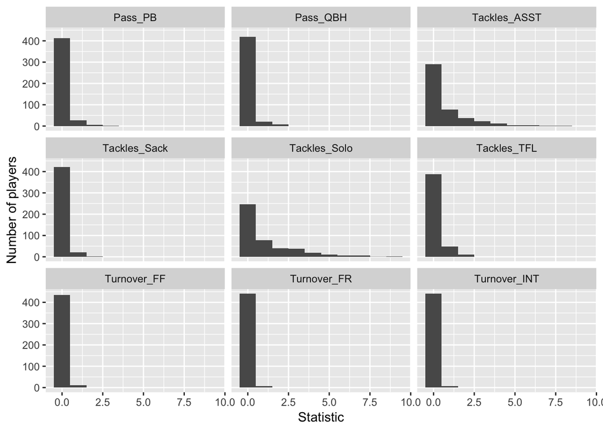

```r
ggplot(defClean, aes(x=Statistic)) +geom_histogram(bins=10) + facet_wrap(~Type) + ylab("Number of players")
```

From here, you can see that interceptions(Turnover_INT) and forced recoveries(Turnover_FR) are most rare. This makes sense, as turnovers are fairly infrequent in football, and for the part, cornerbacks and safeties are in the best position to intercept a pass.

3.Did ISU have better defense against West Virginia or Kansas State? Answer this question by creating a scatterplot with x-axis being the number of solo tackles (by each player) against West Virginia, and y-axis being that against Kansas State. A large number of solo tackles indicates good defense.

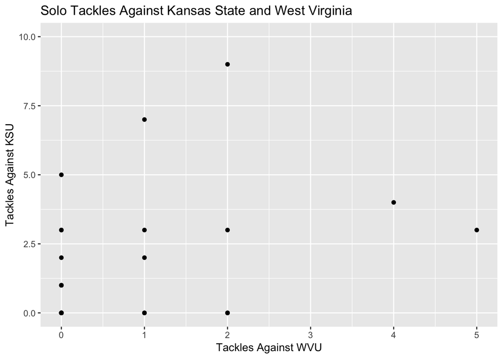

```r
defClean_Solo <- defClean[defClean$Type=='Tackles_Solo',] %>% group_by(Name)
complete <- filter(defClean_Solo, Opponent=='West Virginia' | Opponent=='Kansas State')%>% spread(key=Opponent, value=Statistic)
names(complete) <- c('Name', 'Type', 'KSU','WVU')
complete[is.na(complete)] <- 0
ggplot(complete, aes(x=WVU, y=KSU), group_by(Name)) + geom_point()+ xlim(c(0,5))+ylim(c(0,10)) +xlab("Tackles Against WVU") + ylab("Tackles Against KSU") + ggtitle("Solo Tackles Against Kansas State and West Virginia")
```

From this, better defense was played against Kansas State. While there are not many players that had a large number of solo tackles in both games, there was a larger clump of players that had between 1-4 solo tackles against KSU, that did not perform well against WVU. Therefore, those small increments of fewer tackles led to more overall solo tackles against Kansas State.

4. Separate the Hometown column into two columns, namely the city and the state. Print the first few rows of these two columns. (Hint: look at the sep= argument of separate)

```r
newHometown <- biography
newHometown <- newHometown %>% separate(Hometown, into = c('city', 'state'), sep=",") %>% select(city, state)
head(newHometown)
```

```
## # A tibble: 6 x 2
##   city         state
##   <chr>        <chr>
## 1 Cedar Rapids " Iowa"
## 2 Nixa         " Mo."
## 3 Cedar Rapids " Iowa"
## 4 League City  " Texas"
## 5 Naperville   " Ill."
## 6 Walnut       " Calif."
```

```r
#table(newHometown$city)
#table(newHometown$state)
```

5. How many players are there from each state?

```r
NumPlayer <- biography %>% separate(Hometown, into=c('city', 'state'), sep = ",")  %>% select(Name, state)
head(NumPlayer)
```

```
## # A tibble: 6 x 2
##   Name             state
##   <fct>            <chr>
## 1 Akers, Landen    " Iowa"
## 2 Allen, Chase     " Mo."
## 3 Alt, Gerry       " Iowa"
## 4 Anderson, Cole   " Texas"
## 5 Assalley, Connor " Ill."
## 6 Austin, Aaron    " Calif."
```

```r
(NumPlayer <- NumPlayer %>% group_by(state) %>% summarise(num_player = n()))
```

```
## # A tibble: 25 x 2
##    state        num_player
##    <chr>             <int>
##  1 " Ariz."              3
##  2 " Ark."               2
##  3 " Australia"          2
##  4 " Calif."             8
##  5 " D.C."               1
##  6 " Fla."               8
##  7 " Ga."                2
##  8 " Ill."               5
##  9 " Iowa"              44
## 10 " Kan."               3
## # … with 15 more rows
```

6. Find where do the offensive players come from by joining the offensive data and player biography data appropriately.

```r
newbiography <- biography %>% select(Name, Hometown)
newoffense <- offense %>% select(Name, Opponent, Receiving_REC)
inner_join(newbiography,newoffense)
```

```
## # A tibble: 163 x 4
##    Name          Hometown           Opponent       Receiving_REC
##    <chr>         <chr>              <fct>                  <dbl>
##  1 Akers, Landen Cedar Rapids, Iowa Iowa                       1
##  2 Akers, Landen Cedar Rapids, Iowa Oklahoma                   1
##  3 Akers, Landen Cedar Rapids, Iowa Akron                      1
##  4 Akers, Landen Cedar Rapids, Iowa TCU                        1
##  5 Akers, Landen Cedar Rapids, Iowa Oklahoma State             1
##  6 Akers, Landen Cedar Rapids, Iowa West Virginia              1
##  7 Akers, Landen Cedar Rapids, Iowa Texas Tech                 0
##  8 Akers, Landen Cedar Rapids, Iowa Kansas                     3
##  9 Akers, Landen Cedar Rapids, Iowa Baylor                     0
## 10 Akers, Landen Cedar Rapids, Iowa Texas                      0
## # … with 153 more rows
```

7. Is there a relationship between the weight of a player and the receiving yards (Receiving_YDS)?

```r
biography$Name <- as.character(biography$Name)
offense$Name <- as.character(offense$Name)
newoffense2 <- offense %>% group_by(Name) %>% summarise(Receiving_YDS = mean(Receiving_YDS))
joindata <- inner_join(biography,newoffense2, by='Name')
head(joindata)
```

```
## # A tibble: 6 x 8
##   Name   Position  Height Weight Class   Hometown Highschool  Receiving_YDS
##   <chr>  <chr>     <chr>   <dbl> <chr>   <chr>    <chr>               <dbl>
## 1 Akers… Wide Rec… 6-0       192 Redshi… Cedar R… Washington         13.9
## 2 Allen… Tight End 6-7       240 Redshi… Nixa, M… Nixa               10.5
## 3 Butle… Wide Rec… 6-6       225 Redshi… Baltimo… Travis {Te…       101.
## 4 Eaton… Wide Rec… 6-4       211 Redshi… Norfolk… Pascagoula…        23.4
## 5 Johns… Wide Rec… 5-11      183 Redshi… Little … Central Ar…         0.917
## 6 Jones… Wide Rec… 5-10      185 Junior  Cincinn… Colerain           28.2
```

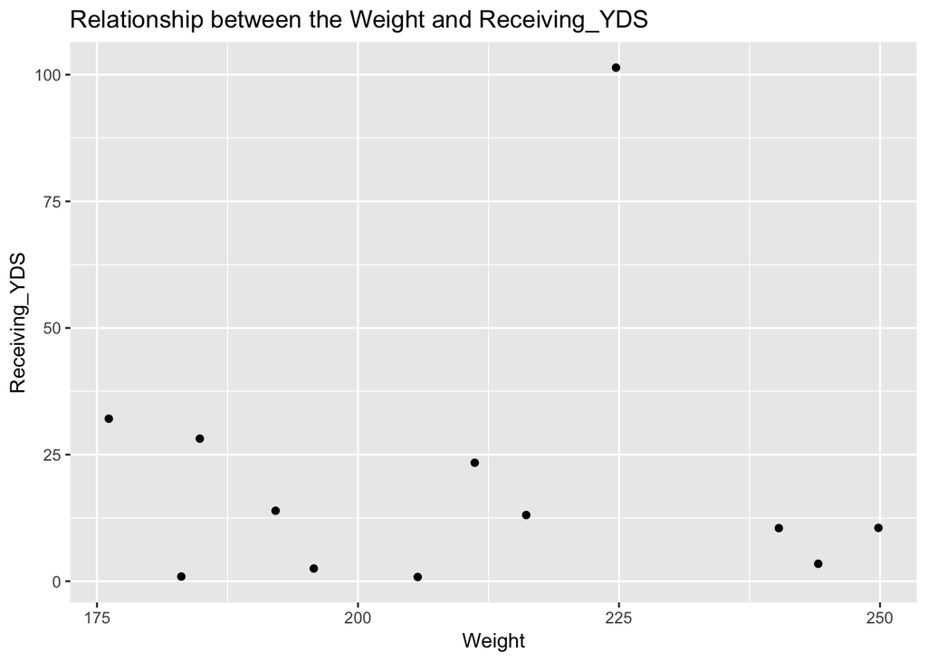

```r
ggplot(joindata, aes(x=Weight, y=Receiving_YDS))+geom_point(position = "jitter")+ggtitle("Relationship between the Weight and Receiving_YDS")
```

We would claim that there is not much of a trend between receiving yards and weight once a receiver weighs around 200lbs. The only receiver listed at 225 is Hakeem Butler, so it would make sense that there is an outlier for his performance.

8. Explore more. Raise a question that can be answered only by looking at two or more data frames. Then answer that question.

Question 1:

```r
yrdsH <- left_join(offClean, SepHeight, by= 'Name')
```

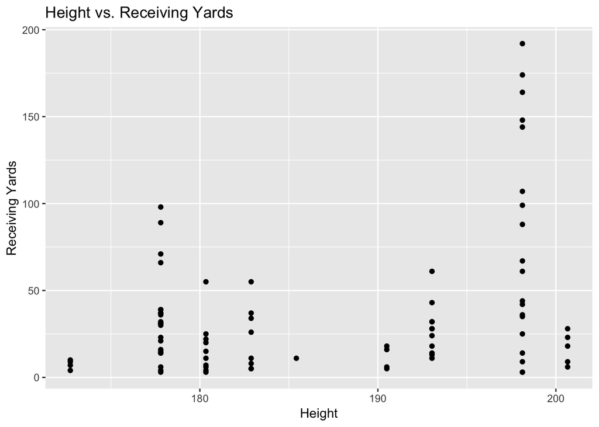

```r
yrdsH <- yrdsH[yrdsH$Receiving_YDS != 0,] %>% filter(!is.na(Name))
ggplot(yrdsH, aes(x= Centimeter, y = Receiving_YDS)) + geom_point() + ggtitle("Height vs. Receiving Yards") + xlab("Height") + ylab("Receiving Yards")
```

Conclusion: This surprised me a little to see that the tallest receivers were not the most successful in terms of overall yards. However, it is important to note that taller receivers may have more trouble if they get pushed around, as well as the fact that the Iowa State receiving corps is not all that deep.

Question 2: I want to check if there is a relationship between the weight and the Tackles_Solo.

```r
biography$Name <- as.character(biography$Name)
defense $Name <- as.character(defense$Name)
newdefense <- defense %>% group_by(Name) %>% summarise(Tackles_Solo = mean(Tackles_Solo))
joindata2 <- inner_join(biography, newdefense, by='Name')
head(joindata2)
```

```
## # A tibble: 6 x 8
##   Name    Position  Height Weight Class   Hometown  Highschool Tackles_Solo
##   <chr>   <chr>     <chr>   <dbl> <chr>   <chr>     <chr>             <dbl>
## 1 Akers,… Wide Rec… 6-0       192 Redshi… Cedar Ra… Washington       0.0769
## 2 Azunna… Defensiv… 6-0       192 Redshi… Grand Pr… Lake Ridge       0.727
## 3 Bailey… Defensiv… 6-3       224 Redshi… Clarksda… Clarksdale       0.0769
## 4 Bailey… Defensiv… 6-2       251 Junior  Jacksonv… Raines           1.23
## 5 Benton… Defensiv… 6-2       256 Redshi… Van Mete… Van Meter        0.846
## 6 Butler… Wide Rec… 6-6       225 Redshi… Baltimor… Travis {T…       0.0769
```

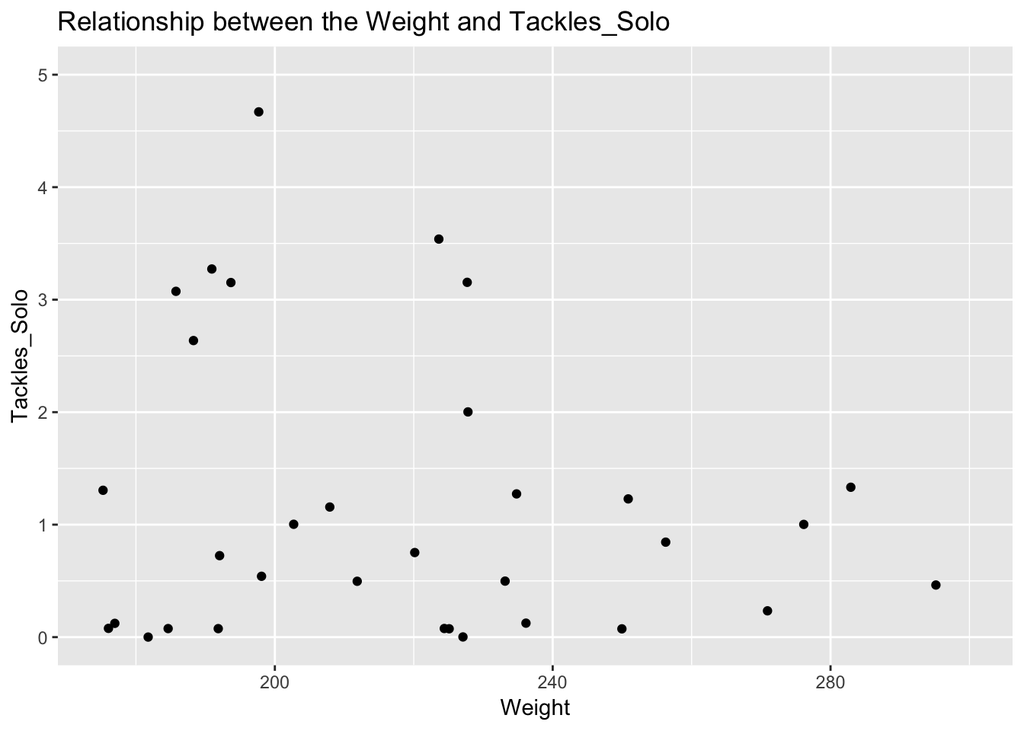

```r
ggplot(joindata2, aes(x=Weight, y=Tackles_Solo))+geom_point(position = "jitter")+ geom_abline(slope = 1, intercept = 0)+ ggtitle("Relationship between the Weight and Tackles_Solo")+xlim(c(175,300))+ylim(c(0,5))
```

Conclusion: There is not really clear and obvious relationship between Tackles_Solo and weight, there might be exits other factors that will effect Tackles_solo. In the plot, it also shows a outlier around weight 200lbs and the tackles_Solo is between 4 and 5.